# Sixth Week: Linear Models

House price prediction

student name

2018-04-13 02:05:07

> با توجه به داده های قیمت منازل لطفا با سوالات زیر پاسخ دهید.

# House Price Prediction

۱. ماتریس همبستگی متغیرهای مختلف را به دست آورده و سپس رسم نمایید. اعداد به دست آمده را با آزمون فرض معناداری همبستگی بسنجید و سپس ده متغیری که همبستگی بالاتری با قیمت دارند را مشخص نمایید.

at first i just use numeric columns. i will use ‘rcorr’ in HMSIC library to find correlation and p-value at the same time .

```r
dic_var = read_delim("data/dictionnaire_variables.csv",delim = ";")
dic_nvx = read_csv("data/dictionnaire_niveaux.csv",
                   col_names = c("variable", "label", "Type")) %>%
  select(1:3)
house = read_csv("data/train.csv")

house2 <- select_if(house, is.numeric)
for(i in 1:ncol(house2)){
  house2[is.na(house2[,i]), i] <- mean(house2[,i], na.rm = TRUE)
}
varcor <- rcorr(as.matrix(house2))
```

**p_values**

```r
varcor$P
```

```
                      Id   MSSubClass  LotFrontage      LotArea
Id                    NA 6.701541e-01 7.136195e-01 2.045095e-01
MSSubClass    0.67015407           NA 0.000000e+00 8.194126e-08
LotFrontage   0.71361949 0.000000e+00           NA 0.000000e+00
LotArea       0.20450947 8.194126e-08 0.000000e+00           NA
OverallQual   0.27876166 2.127766e-01 0.000000e+00 5.105509e-05
OverallCond   0.63023734 2.342025e-02 4.019570e-02 8.296279e-01
YearBuilt     0.62742402 2.875793e-01 1.813802e-05 5.869923e-01
YearRemodAdd  0.40095861 1.211631e-01 2.052217e-03 5.985903e-01
MasVnrArea    0.05534401 3.824712e-01 1.536393e-11 6.995925e-05
BsmtFinSF1    0.84789461 7.598820e-03 2.220446e-16 0.000000e+00
BsmtFinSF2    0.81977751 1.210779e-02 8.388577e-02 2.068606e-05
BsmtUnfSF     0.76179797 6.637589e-08 3.979767e-06 9.203746e-01
TotalBsmtSF   0.55618315 0.000000e+00 0.000000e+00 0.000000e+00
1stFlrSF      0.68862577 0.000000e+00 0.000000e+00 0.000000e+00
2ndFlrSF      0.83100987 0.000000e+00 5.433170e-03 5.144266e-02
LowQualFinSF  0.09114212 7.586521e-02 1.827783e-01 8.552305e-01
GrLivArea     0.75212677 4.213734e-03 0.000000e+00 0.000000e+00
BsmtFullBath  0.93037678 8.939735e-01 4.587930e-04 1.230800e-09
BsmtHalfBath  0.44157857 9.290423e-01 8.022392e-01 6.646033e-02
FullBath      0.83108121 4.502112e-07 3.634426e-12 1.360045e-06
HalfBath      0.79564293 8.788081e-12 6.365788e-02 5.861562e-01
BedroomAbvGr  0.14972539 3.708290e-01 0.000000e+00 4.519871e-06
KitchenAbvGr  0.91029199 0.000000e+00 8.335889e-01 4.971427e-01
TotRmsAbvGrd  0.29829728 1.230183e-01 0.000000e+00 2.460254e-13
Fireplaces    0.45030914 8.175110e-02 0.000000e+00 0.000000e+00
GarageYrBlt   0.99785707 1.566879e-03 1.834203e-02 3.545896e-01
GarageCars    0.52697684 1.255479e-01 0.000000e+00 2.706813e-09
GarageArea    0.50078128 1.592242e-04 0.000000e+00 3.802736e-12
WoodDeckSF    0.25765815 6.310397e-01 2.136524e-03 4.001022e-11
OpenPorchSF   0.98547360 8.158485e-01 1.210210e-07 1.185832e-03
EnclosedPorch 0.91216945 6.458454e-01 7.110477e-01 4.837906e-01
3SsnPorch     0.07485435 9.414954e-02 1.520968e-02 4.355273e-01
ScreenPorch   0.95949789 3.202578e-01 1.517836e-01 9.924777e-02
PoolArea      0.02929065 7.518384e-01 5.393463e-13 2.979905e-03
MiscVal       0.81163292 7.692691e-01 9.071905e-01 1.459891e-01
MoSold        0.41886873 6.040063e-01 6.982030e-01 9.633078e-01
YrSold        0.97832070 4.137257e-01 7.964813e-01 5.861053e-01
SalePrice     0.40269380 1.266472e-03 0.000000e+00 0.000000e+00
               OverallQual  OverallCond    YearBuilt YearRemodAdd
```

[output cut: 335 more lines]

```
TotRmsAbvGrd  1.874597e-01 0.000000e+00
Fireplaces    3.575543e-01 0.000000e+00
GarageYrBlt   9.699819e-01 0.000000e+00
GarageCars    1.351896e-01 0.000000e+00
GarageArea    2.958337e-01 0.000000e+00
WoodDeckSF    3.951420e-01 0.000000e+00
OpenPorchSF   2.769526e-02 0.000000e+00
EnclosedPorch 7.050056e-01 8.255770e-07
3SsnPorch     4.765432e-01 8.858170e-02
ScreenPorch   6.830660e-01 1.972140e-05
PoolArea      2.256081e-02 4.073490e-04
MiscVal       8.514187e-01 4.184863e-01
MoSold        2.230274e-08 7.612758e-02
YrSold                  NA 2.694132e-01
SalePrice     2.694132e-01           NA
```

**PLOT CORRELAION** for ploting correlation i use corplot and significance interval to leave blank insignificant test .

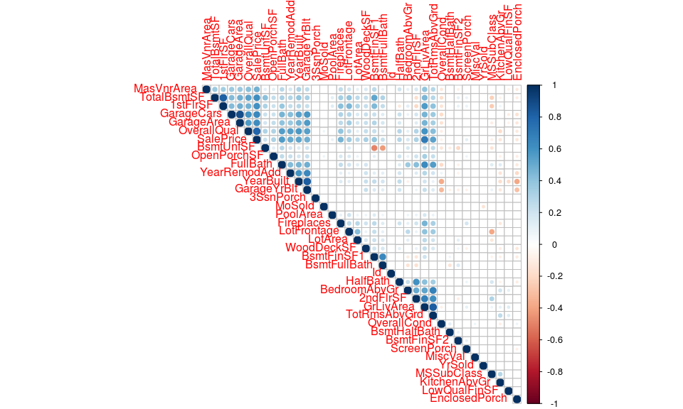

```r
library(corrplot)
# Insignificant correlations are leaved blank
corrplot(varcor$r, type="upper", order="hclust",
         p.mat = varcor$P, sig.level = 0.01, insig = "blank")
```

finding 10 most correlated to price :

```r
varcor$r[,"SalePrice"]
```

```
           Id    MSSubClass   LotFrontage       LotArea   OverallQual
  -0.02191672   -0.08428414    0.35179910    0.26384335    0.79098160
  OverallCond     YearBuilt  YearRemodAdd    MasVnrArea    BsmtFinSF1
  -0.07785589    0.52289733    0.50710097    0.47749305    0.38641981
   BsmtFinSF2     BsmtUnfSF   TotalBsmtSF      1stFlrSF      2ndFlrSF
  -0.01137812    0.21447911    0.61358055    0.60585218    0.31933380
 LowQualFinSF     GrLivArea  BsmtFullBath  BsmtHalfBath      FullBath
  -0.02560613    0.70862448    0.22712223   -0.01684415    0.56066376
     HalfBath  BedroomAbvGr  KitchenAbvGr  TotRmsAbvGrd    Fireplaces
   0.28410768    0.16821315   -0.13590737    0.53372316    0.46692884
  GarageYrBlt    GarageCars    GarageArea    WoodDeckSF   OpenPorchSF
   0.48636168    0.64040920    0.62343144    0.32441344    0.31585623
EnclosedPorch     3SsnPorch   ScreenPorch      PoolArea       MiscVal
  -0.12857796    0.04458367    0.11144657    0.09240355   -0.02118958
       MoSold        YrSold     SalePrice
   0.04643225   -0.02892259    1.00000000
```

```r
 ele_cor <- names(sort(varcor$r[,"SalePrice"], decreasing = T))[1:11]
```

۲. در یک تصویر نمودار پراکنش دو به دو ده متغیر بدست آمده به همراه قیمت را رسم نمایید و هم خطی بودن متغیرها را بررسی کنید

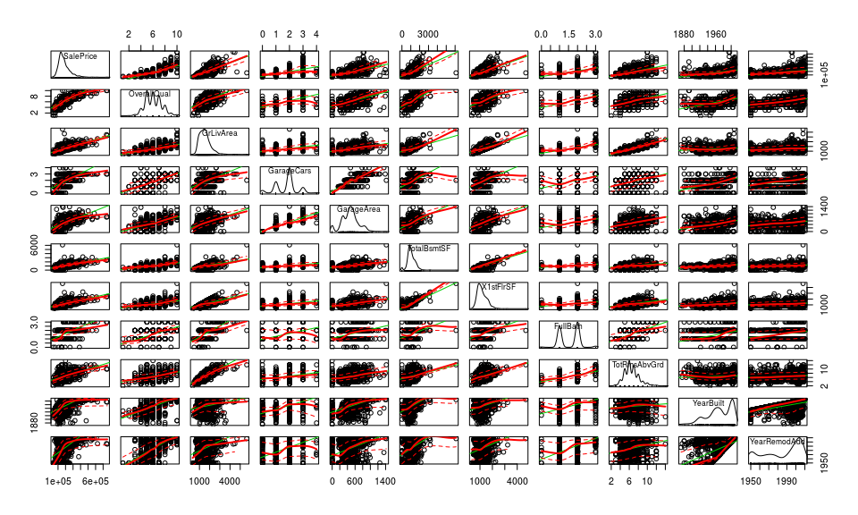

```r
library("car")
house10 <- as.matrix(house2[,ele_cor])
scatterplotMatrix(house10)
```

۳. یک مدل خطی بر اساس ده متغیر برای پیش بینی قیمت برازش دهید. و سپس خلاصه نتایج مدل را به دست آورید.

```r
house10 <- select(house,ele_cor)
fit = lm(SalePrice ~ . ,
         data = house10)
summary(fit)
```

```
Call:
lm(formula = SalePrice ~ ., data = house10)

Residuals:
    Min      1Q  Median      3Q     Max
-489958  -19316   -1948   16020  290558

Coefficients:
               Estimate Std. Error t value Pr(>|t|)
(Intercept)  -1.186e+06  1.291e+05  -9.187  < 2e-16 ***
OverallQual   1.960e+04  1.190e+03  16.472  < 2e-16 ***
GrLivArea     5.130e+01  4.233e+00  12.119  < 2e-16 ***
GarageCars    1.042e+04  3.044e+03   3.422 0.000639 ***
GarageArea    1.495e+01  1.031e+01   1.450 0.147384
TotalBsmtSF   1.986e+01  4.295e+00   4.625 4.09e-06 ***
`1stFlrSF`    1.417e+01  4.930e+00   2.875 0.004097 **
FullBath     -6.791e+03  2.682e+03  -2.532 0.011457 *
TotRmsAbvGrd  3.310e+01  1.119e+03   0.030 0.976404
YearBuilt     2.682e+02  5.035e+01   5.328 1.15e-07 ***
YearRemodAdd  2.965e+02  6.363e+01   4.659 3.47e-06 ***
---
Signif. codes:  0 '***' 0.001 '**' 0.01 '*' 0.05 '.' 0.1 ' ' 1

Residual standard error: 37920 on 1449 degrees of freedom
Multiple R-squared:  0.7737,    Adjusted R-squared:  0.7721
F-statistic: 495.4 on 10 and 1449 DF,  p-value: < 2.2e-16
```

۴. نمودار قیمت واقعی و قیمت پیش بینی را رسم نمایید و خوب بودن مدل را ارزیابی کنید.

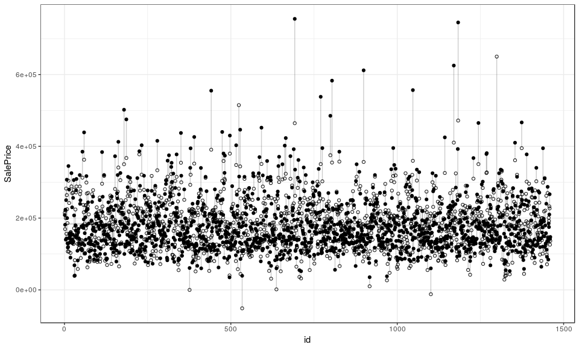

```r
house10$pre_sale = predict(fit)
house10$res_sale = residuals(fit)
house10$id = house$Id


ggplot(house10, aes(x = id  ,y = SalePrice)) +
  geom_smooth(method = "lm", se = FALSE, color = "lightgrey") +  # Plot regression slope
  geom_segment(aes(xend = id, yend = pre_sale), alpha = .2) +  # alpha to fade lines
  geom_point() +
  geom_point(aes(y = pre_sale), shape = 1) +
  theme_bw()  # Add theme for cleaner look
```

for ploting i connect predicted price to real value . black dots are real Sale price . it seams that in some price we get a good fit by lm .

۵. مقدار R-squared مدل را به دست آورید. آیا بر اساس این کمیت مدل به خوبی به داده ها برازش داده شده است؟ کمیت F-statistic را در خلاصه مدل تفسیر نمایید.

```r
summary(fit)
```

```
Call:
lm(formula = SalePrice ~ ., data = house10)

Residuals:
    Min      1Q  Median      3Q     Max
-489958  -19316   -1948   16020  290558

Coefficients:
               Estimate Std. Error t value Pr(>|t|)
(Intercept)  -1.186e+06  1.291e+05  -9.187  < 2e-16 ***
OverallQual   1.960e+04  1.190e+03  16.472  < 2e-16 ***
GrLivArea     5.130e+01  4.233e+00  12.119  < 2e-16 ***
GarageCars    1.042e+04  3.044e+03   3.422 0.000639 ***
GarageArea    1.495e+01  1.031e+01   1.450 0.147384
TotalBsmtSF   1.986e+01  4.295e+00   4.625 4.09e-06 ***
`1stFlrSF`    1.417e+01  4.930e+00   2.875 0.004097 **
FullBath     -6.791e+03  2.682e+03  -2.532 0.011457 *
TotRmsAbvGrd  3.310e+01  1.119e+03   0.030 0.976404
YearBuilt     2.682e+02  5.035e+01   5.328 1.15e-07 ***
YearRemodAdd  2.965e+02  6.363e+01   4.659 3.47e-06 ***
---
Signif. codes:  0 '***' 0.001 '**' 0.01 '*' 0.05 '.' 0.1 ' ' 1

Residual standard error: 37920 on 1449 degrees of freedom
Multiple R-squared:  0.7737,    Adjusted R-squared:  0.7721
F-statistic: 495.4 on 10 and 1449 DF,  p-value: < 2.2e-16
```

so R-squerd = 0.7737 means our model can can explain 77% of variation in observed data valus . as we know f-statistic in here computed by F = [R² / (k-1)] / [ (1-R²) (n-k) ] that shows if this R2 -squered can mean that by adding these ten variable to model instead of zero variable (mean value) our model can explain this variation on observed data . F Statistic gives us a power to judge whether that relationship is statistically significant in other words it comments on whether or R² is significant or not. for F-stat = 495.4 and DF =10 we get too small p-value that we can reject that Additional variables do not provide value taken together.

۶. بر اساس p-value سطح معناداری ضرایب تصمیم بگیرید که چه متغیرهایی در مدل سازی استفاده شود. بر اساس متغیرهای جدید دوباره مدل سازی کنید و نتایج رو گزارش دهید.

first i will get p_values and get those with less than 0.01;

```r
summary(fit)$coefficients[,4] < 0.01
```

```
 (Intercept)  OverallQual    GrLivArea   GarageCars   GarageArea
        TRUE         TRUE         TRUE         TRUE        FALSE
 TotalBsmtSF   `1stFlrSF`     FullBath TotRmsAbvGrd    YearBuilt
        TRUE         TRUE        FALSE        FALSE         TRUE
YearRemodAdd
        TRUE
```

```r
house10_new<- select(house,ele_cor)
### fit new model
fit_new = lm(SalePrice ~ . -FullBath -TotRmsAbvGrd -GarageArea ,
         data = house10_new)
summary(fit_new)
```

```
Call:
lm(formula = SalePrice ~ . - FullBath - TotRmsAbvGrd - GarageArea,
    data = house10_new)

Residuals:
    Min      1Q  Median      3Q     Max
-471221  -19922   -1681   16246  291326

Coefficients:
               Estimate Std. Error t value Pr(>|t|)
(Intercept)  -1.075e+06  1.217e+05  -8.833  < 2e-16 ***
OverallQual   1.949e+04  1.190e+03  16.377  < 2e-16 ***
GrLivArea     4.768e+01  2.713e+00  17.576  < 2e-16 ***
GarageCars    1.381e+04  1.820e+03   7.586 5.85e-14 ***
TotalBsmtSF   2.174e+01  4.249e+00   5.117 3.53e-07 ***
`1stFlrSF`    1.407e+01  4.925e+00   2.856  0.00435 **
YearBuilt     2.292e+02  4.799e+01   4.777 1.96e-06 ***
YearRemodAdd  2.768e+02  6.337e+01   4.367 1.35e-05 ***
---
Signif. codes:  0 '***' 0.001 '**' 0.01 '*' 0.05 '.' 0.1 ' ' 1

Residual standard error: 38010 on 1452 degrees of freedom
Multiple R-squared:  0.7722,    Adjusted R-squared:  0.7711
F-statistic: 703.2 on 7 and 1452 DF,  p-value: < 2.2e-16
```

thw Residual standard error increased. other wise the R-Squered deacreased a little that i dont think this much can show anything . ***

۷. مدل خود را بر اساس باقی مانده نقص یابی کنید. سه محک normality, independance, Constant Variance را در نقص یابی خود در نظر بگیرید.

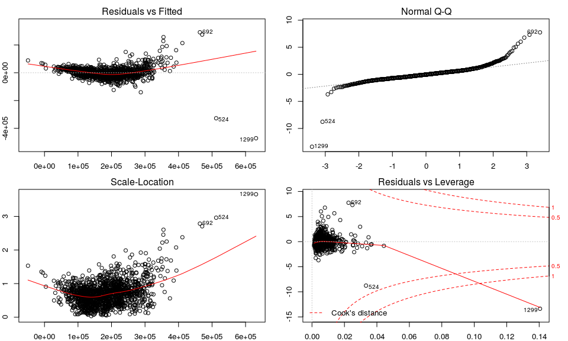

```r
# Change the layout to 2x2 to accommodate all plots
par(mfrow=c(2,2))
par(mar = rep(2, 4))

# Diagnostic Plots
plot(fit_new)
```

**test of Constant Variance**: by scale location we can test this that for large values of price the variance of residul predicted value gets higher. but for most of residual value we get variance of near constant 1 . **Normality** as we can find from normal-QQ plot data are some how fitted to the line for all value accept for high quantiles. **independance** for testing independence of errors in diffrent predicted price we had to find normality distribution of errors :

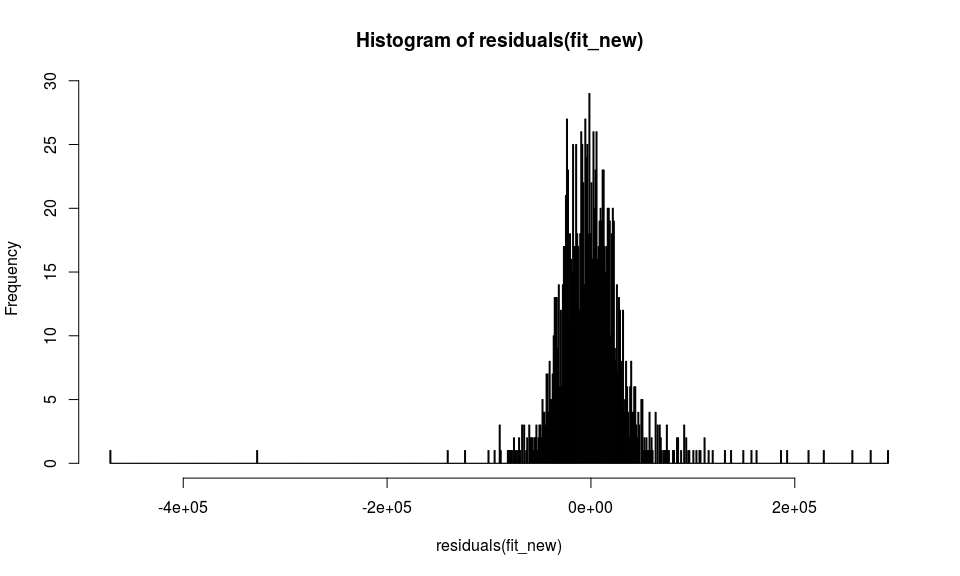

```r
hist(residuals(fit_new),1000)
```

as you can see it is normal with zero mean . ***

۸. داده ها را به پنج قسمت تقسیم کنید. بر اساس چهار قسمت مدل خطی را بسازید و صحت مدل را برای یک قسمت باقی مانده را تست کنید. خطای پیش بینی شما چقدر است؟

```r
train = house10_new[1:1168,]
test = house10_new[1168:1460,]
fit = lm(SalePrice ~ . ,
         data = train )
pre_test <- predict(fit,test)
rss <- mean((pre_test-test[1,])^2)
```

[output not shown]

۹. آیا قیمت ربط غیر خطی با یکی از ده متغیر استفاده شده دارد؟ بر اساس دستاوردهای خود مدل را بهتر نمایید.

```r
vcor <- rcorr(as.matrix(house10_new) , type = 'spearman')

fit_best = lm(SalePrice ~ (.)^2,data = house10_new)
summary(fit_best)
```

```
Call:
lm(formula = SalePrice ~ (.)^2, data = house10_new)

Residuals:
    Min      1Q  Median      3Q     Max
-373821  -15045    -198   13626  179215

Coefficients:
                            Estimate Std. Error t value Pr(>|t|)
(Intercept)               -5.497e+06  8.348e+06  -0.658 0.510357
OverallQual                1.327e+04  1.076e+05   0.123 0.901833
GrLivArea                  4.787e+02  4.704e+02   1.018 0.308964
GarageCars                 4.027e+05  3.020e+05   1.333 0.182614
GarageArea                -2.439e+03  1.062e+03  -2.297 0.021777 *
TotalBsmtSF               -9.406e+01  5.008e+02  -0.188 0.851044
`1stFlrSF`                -1.367e+01  5.943e+02  -0.023 0.981646
FullBath                  -4.330e+05  2.657e+05  -1.630 0.103421
TotRmsAbvGrd              -1.497e+05  1.195e+05  -1.253 0.210444
YearBuilt                  3.499e+03  4.355e+03   0.803 0.421846
YearRemodAdd               2.215e+03  4.265e+03   0.519 0.603666
OverallQual:GrLivArea      1.126e+01  3.594e+00   3.134 0.001762 **
OverallQual:GarageCars     1.831e+03  2.748e+03   0.666 0.505506
OverallQual:GarageArea    -1.500e+00  9.513e+00  -0.158 0.874734
OverallQual:TotalBsmtSF    9.164e+00  3.940e+00   2.326 0.020170 *
OverallQual:`1stFlrSF`     1.172e+01  4.852e+00   2.415 0.015849 *
OverallQual:FullBath      -4.747e+03  2.312e+03  -2.053 0.040245 *
OverallQual:TotRmsAbvGrd   4.873e+02  9.955e+02   0.489 0.624569
OverallQual:YearBuilt     -6.326e+01  4.191e+01  -1.509 0.131445
OverallQual:YearRemodAdd   4.471e+01  5.962e+01   0.750 0.453453
GrLivArea:GarageCars       3.152e+01  9.963e+00   3.164 0.001590 **
GrLivArea:GarageArea      -4.644e-02  3.361e-02  -1.382 0.167299
GrLivArea:TotalBsmtSF     -2.025e-02  1.475e-02  -1.373 0.169981
GrLivArea:`1stFlrSF`      -5.001e-02  1.607e-02  -3.111 0.001901 **
GrLivArea:FullBath         2.638e+01  7.758e+00   3.400 0.000692 ***
GrLivArea:TotRmsAbvGrd    -8.789e-01  1.650e+00  -0.533 0.594436
GrLivArea:YearBuilt        3.627e-01  1.463e-01   2.479 0.013310 *
GrLivArea:YearRemodAdd    -6.026e-01  2.441e-01  -2.469 0.013682 *
GarageCars:GarageArea     -9.221e+00  5.487e+00  -1.680 0.093093 .
GarageCars:TotalBsmtSF    -1.348e+01  1.093e+01  -1.233 0.217893
GarageCars:`1stFlrSF`      2.697e+01  1.297e+01   2.080 0.037709 *
```

[output cut: 16 more lines]

```
`1stFlrSF`:TotRmsAbvGrd    1.425e+00  4.017e+00   0.355 0.722821
`1stFlrSF`:YearBuilt      -2.842e-01  2.379e-01  -1.195 0.232429
`1stFlrSF`:YearRemodAdd    2.923e-01  2.640e-01   1.107 0.268401
FullBath:TotRmsAbvGrd      3.468e+02  1.960e+03   0.177 0.859596
FullBath:YearBuilt         7.952e+01  9.704e+01   0.819 0.412698
FullBath:YearRemodAdd      1.427e+02  1.329e+02   1.073 0.283262
TotRmsAbvGrd:YearBuilt    -5.380e+01  4.130e+01  -1.302 0.192978
TotRmsAbvGrd:YearRemodAdd  1.254e+02  6.045e+01   2.075 0.038157 *
YearBuilt:YearRemodAdd    -1.445e+00  2.219e+00  -0.651 0.515010
---
Signif. codes:  0 '***' 0.001 '**' 0.01 '*' 0.05 '.' 0.1 ' ' 1

Residual standard error: 29640 on 1404 degrees of freedom
Multiple R-squared:  0.866, Adjusted R-squared:  0.8608
F-statistic:   165 on 55 and 1404 DF,  p-value: < 2.2e-16
```

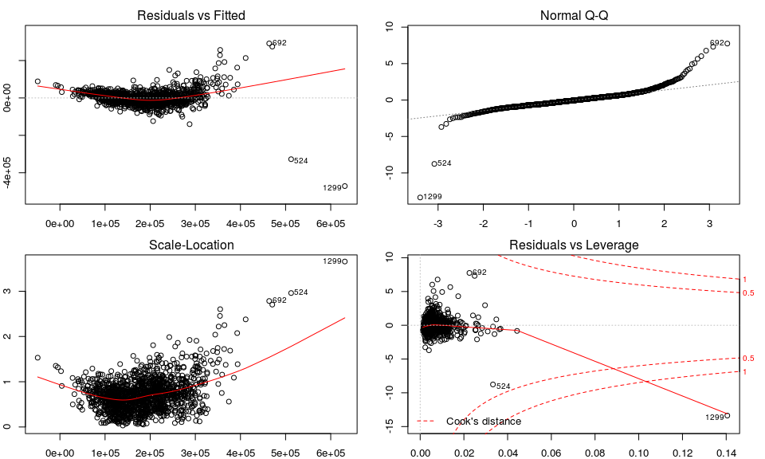

```r
par(mfrow=c(2,2))
par(mar = rep(2, 4))

# Diagnostic Plots
plot(fit_new)
```

۱۰. بر اساس مدل نهایی به دست آمده نتایج پیش بینی خود را بر روی test.csv به دست آورید و در سایت kaggle در مسابقه House Prices: Advanced Regression Techniques بارگذاری نمایید. سپس لینک رتبه و عدد آن را ضمیمه تمرین کنید.

```r
test_data <- read_csv("data/test.csv")
test_data <- select_if(test_data, is.numeric)
for(i in 1:ncol(test_data)){
  test_data[is.na(test_data[,i]), i] <- mean(test_data[,i], na.rm = TRUE)
}
test_pred <- predict(fit_best, test_data)
submission <- cbind(Id=test_data$Id,SalePrice=test_pred)
colnames(submission) <- c("Id","SalePrice")

write.csv(submission,file="saleh_submission.csv",row.names=FALSE)
```

**kaggle** my score in kaggle is 0.16623 . my username is miner4data .

[figure not shown]